# Subset Selection, Shrinkage Methods and Dimension Reduction

Phoebe Tan

2023-08-26

**Subset Selection:**

Select a subset of predictors believed to be related to the response, then fit a model on this reduced subset using regression.

**Shrinkage (Regularisation):**

Fit a model involving all predictors, but shrink the coefficients toward zero, potentially leading to some coefficients being exactly zero and performing variable selection.

**Dimension Reduction**

Project predictors into a lower-dimensional space using linear combinations, then fit a regression model on these projections to achieve a simpler model and potentially address multicollinearity.

## Preprocessing Data

```r
library(data.table)
library(ISLR2)
set.seed(2)
data=Hitters
str(Hitters)
```

```
## 'data.frame':    322 obs. of  20 variables:
##  $ AtBat    : int  293 315 479 496 321 594 185 298 323 401 ...
##  $ Hits     : int  66 81 130 141 87 169 37 73 81 92 ...
##  $ HmRun    : int  1 7 18 20 10 4 1 0 6 17 ...
##  $ Runs     : int  30 24 66 65 39 74 23 24 26 49 ...
##  $ RBI      : int  29 38 72 78 42 51 8 24 32 66 ...
##  $ Walks    : int  14 39 76 37 30 35 21 7 8 65 ...
##  $ Years    : int  1 14 3 11 2 11 2 3 2 13 ...
##  $ CAtBat   : int  293 3449 1624 5628 396 4408 214 509 341 5206 ...
##  $ CHits    : int  66 835 457 1575 101 1133 42 108 86 1332 ...
##  $ CHmRun   : int  1 69 63 225 12 19 1 0 6 253 ...
##  $ CRuns    : int  30 321 224 828 48 501 30 41 32 784 ...
##  $ CRBI     : int  29 414 266 838 46 336 9 37 34 890 ...
##  $ CWalks   : int  14 375 263 354 33 194 24 12 8 866 ...
##  $ League   : Factor w/ 2 levels "A","N": 1 2 1 2 2 1 2 1 2 1 ...
##  $ Division : Factor w/ 2 levels "E","W": 1 2 2 1 1 2 1 2 2 1 ...
##  $ PutOuts  : int  446 632 880 200 805 282 76 121 143 0 ...
##  $ Assists  : int  33 43 82 11 40 421 127 283 290 0 ...
##  $ Errors   : int  20 10 14 3 4 25 7 9 19 0 ...
##  $ Salary   : num  NA 475 480 500 91.5 750 70 100 75 1100 ...
##  $ NewLeague: Factor w/ 2 levels "A","N": 1 2 1 2 2 1 1 1 2 1 ...
```

```r
head(Hitters)
```

```
##                   AtBat Hits HmRun Runs RBI Walks Years CAtBat CHits CHmRun
## -Andy Allanson      293   66     1   30  29    14     1    293    66      1
## -Alan Ashby         315   81     7   24  38    39    14   3449   835     69
## -Alvin Davis        479  130    18   66  72    76     3   1624   457     63
## -Andre Dawson       496  141    20   65  78    37    11   5628  1575    225
## -Andres Galarraga   321   87    10   39  42    30     2    396   101     12
## -Alfredo Griffin    594  169     4   74  51    35    11   4408  1133     19
##                   CRuns CRBI CWalks League Division PutOuts Assists Errors
## -Andy Allanson       30   29     14      A        E     446      33     20
## -Alan Ashby         321  414    375      N        W     632      43     10
## -Alvin Davis        224  266    263      A        W     880      82     14
## -Andre Dawson       828  838    354      N        E     200      11      3
## -Andres Galarraga    48   46     33      N        E     805      40      4
## -Alfredo Griffin    501  336    194      A        W     282     421     25
##                   Salary NewLeague
## -Andy Allanson        NA         A
## -Alan Ashby        475.0         N
## -Alvin Davis       480.0         A
## -Andre Dawson      500.0         N
## -Andres Galarraga   91.5         N
## -Alfredo Griffin   750.0         A
```

```r
sum(is.na(Hitters$Salary))
```

```
## [1] 59
```

```r
#There are NA values. Thus we omit them
Hitters= na.omit(Hitters)
Hitters= subset(Hitters, select= -c(League,Division,NewLeague))
str(Hitters)
```

```
## 'data.frame':    263 obs. of  17 variables:
##  $ AtBat  : int  315 479 496 321 594 185 298 323 401 574 ...
##  $ Hits   : int  81 130 141 87 169 37 73 81 92 159 ...
##  $ HmRun  : int  7 18 20 10 4 1 0 6 17 21 ...
##  $ Runs   : int  24 66 65 39 74 23 24 26 49 107 ...
##  $ RBI    : int  38 72 78 42 51 8 24 32 66 75 ...
##  $ Walks  : int  39 76 37 30 35 21 7 8 65 59 ...
##  $ Years  : int  14 3 11 2 11 2 3 2 13 10 ...
##  $ CAtBat : int  3449 1624 5628 396 4408 214 509 341 5206 4631 ...
##  $ CHits  : int  835 457 1575 101 1133 42 108 86 1332 1300 ...
##  $ CHmRun : int  69 63 225 12 19 1 0 6 253 90 ...
##  $ CRuns  : int  321 224 828 48 501 30 41 32 784 702 ...
##  $ CRBI   : int  414 266 838 46 336 9 37 34 890 504 ...
##  $ CWalks : int  375 263 354 33 194 24 12 8 866 488 ...
##  $ PutOuts: int  632 880 200 805 282 76 121 143 0 238 ...
##  $ Assists: int  43 82 11 40 421 127 283 290 0 445 ...
##  $ Errors : int  10 14 3 4 25 7 9 19 0 22 ...
##  $ Salary : num  475 480 500 91.5 750 ...
```

## Feature selection

```r
#install.packages('leaps')
library(leaps)
#Now, we apply regsubsets() to the training set in order to perform best subset selection.
regfit.full = regsubsets(Salary ~ ., data = Hitters, nvmax = 16) #nvmax= is the maximum number of variables to include in the model
reg.summary = summary(regfit.full)
reg.summary
```

```
## Subset selection object
## Call: regsubsets.formula(Salary ~ ., data = Hitters, nvmax = 16)
## 16 Variables  (and intercept)
##         Forced in Forced out
## AtBat       FALSE      FALSE
## Hits        FALSE      FALSE
## HmRun       FALSE      FALSE
## Runs        FALSE      FALSE
## RBI         FALSE      FALSE
## Walks       FALSE      FALSE
## Years       FALSE      FALSE
## CAtBat      FALSE      FALSE
## CHits       FALSE      FALSE
## CHmRun      FALSE      FALSE
## CRuns       FALSE      FALSE
## CRBI        FALSE      FALSE
## CWalks      FALSE      FALSE
## PutOuts     FALSE      FALSE
## Assists     FALSE      FALSE
## Errors      FALSE      FALSE
## 1 subsets of each size up to 16
## Selection Algorithm: exhaustive
##           AtBat Hits HmRun Runs RBI Walks Years CAtBat CHits CHmRun CRuns CRBI
## 1  ( 1 )  " "   " "  " "   " "  " " " "   " "   " "    " "   " "    " "   "*"
## 2  ( 1 )  " "   "*"  " "   " "  " " " "   " "   " "    " "   " "    " "   "*"
## 3  ( 1 )  " "   "*"  " "   " "  " " " "   " "   " "    " "   " "    " "   "*"
## 4  ( 1 )  "*"   "*"  " "   " "  " " " "   " "   " "    " "   " "    " "   "*"
## 5  ( 1 )  "*"   "*"  " "   " "  " " "*"   " "   " "    " "   " "    " "   "*"
## 6  ( 1 )  "*"   "*"  " "   " "  " " "*"   " "   " "    " "   " "    "*"   " "
## 7  ( 1 )  "*"   "*"  " "   " "  " " "*"   " "   " "    " "   "*"    "*"   " "
## 8  ( 1 )  "*"   "*"  " "   " "  " " "*"   " "   "*"    " "   " "    "*"   "*"
## 9  ( 1 )  "*"   "*"  " "   " "  " " "*"   " "   "*"    " "   " "    "*"   "*"
## 10  ( 1 ) "*"   "*"  " "   "*"  " " "*"   " "   "*"    " "   " "    "*"   "*"
## 11  ( 1 ) "*"   "*"  " "   "*"  " " "*"   " "   "*"    " "   " "    "*"   "*"
## 12  ( 1 ) "*"   "*"  "*"   "*"  " " "*"   " "   "*"    " "   " "    "*"   "*"
## 13  ( 1 ) "*"   "*"  "*"   "*"  " " "*"   " "   "*"    "*"   " "    "*"   "*"
## 14  ( 1 ) "*"   "*"  "*"   "*"  " " "*"   "*"   "*"    " "   "*"    "*"   "*"
## 15  ( 1 ) "*"   "*"  "*"   "*"  " " "*"   "*"   "*"    "*"   "*"    "*"   "*"
## 16  ( 1 ) "*"   "*"  "*"   "*"  "*" "*"   "*"   "*"    "*"   "*"    "*"   "*"
##           CWalks PutOuts Assists Errors
## 1  ( 1 )  " "    " "     " "     " "
## 2  ( 1 )  " "    " "     " "     " "
## 3  ( 1 )  " "    "*"     " "     " "
## 4  ( 1 )  " "    "*"     " "     " "
## 5  ( 1 )  " "    "*"     " "     " "
## 6  ( 1 )  "*"    "*"     " "     " "
## 7  ( 1 )  "*"    "*"     " "     " "
## 8  ( 1 )  "*"    "*"     " "     " "
## 9  ( 1 )  "*"    "*"     "*"     " "
## 10  ( 1 ) "*"    "*"     "*"     " "
## 11  ( 1 ) "*"    "*"     "*"     "*"
## 12  ( 1 ) "*"    "*"     "*"     "*"
## 13  ( 1 ) "*"    "*"     "*"     "*"
## 14  ( 1 ) "*"    "*"     "*"     "*"
## 15  ( 1 ) "*"    "*"     "*"     "*"
## 16  ( 1 ) "*"    "*"     "*"     "*"
```

From the summary above, the best 1- variable model is the one with CRBI as the predictor. The best 2 variable model is with Hits + CRBI. The best 3 variable model is with Hits + CRBI + PutOuts and so on.

*A natural question is: which of these best models should we finally choose for our predictive analytics?*

#Choosing the optimal model

```r
names(reg.summary)            #Model selection criteria: Adjusted R2, Cp and BIC
```

```
## [1] "which"  "rsq"    "rss"    "adjr2"  "cp"     "bic"    "outmat" "obj"
```

```r
data.frame(
  Adj.R2 = which.max(reg.summary$adjr2),
  CP = which.min(reg.summary$cp),
  BIC = which.min(reg.summary$bic)
)
```

```
##   Adj.R2 CP BIC
## 1      9  9   7
```

With BIC, the best model is the one with 7 variables. However, using Adjusted R2 and CP, we should go for the one with 9 variables.

## Using Additional Strategies

```r
wh=reg.summary$which;View(wh)
reg.summary$adjr2
```

```
##  [1] 0.3188503 0.4208024 0.4450753 0.4621594 0.4805047 0.4855144 0.4983282
##  [8] 0.5036515 0.5086408 0.5077531 0.5064485 0.5049397 0.5031603 0.5012591
## [15] 0.4992625 0.4972271
```

```r
reg.summary$rsq
```

```
##  [1] 0.3214501 0.4252237 0.4514294 0.4703707 0.4904187 0.4972965 0.5117316
##  [8] 0.5188071 0.5255196 0.5265411 0.5271702 0.5276142 0.5278127 0.5279094
## [15] 0.5279307 0.5279308
```

*plot adjr2*

```r
#install.packages('ggvis')
library(ggvis)
```

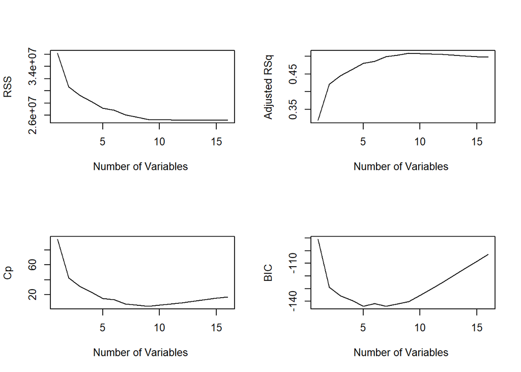

```r
adjr2 <- as.data.frame(reg.summary$adjr2)
names(adjr2) <- "adjr2"
par(mfrow=c(2,2))
plot(reg.summary$rss ,xlab="Number of Variables ",ylab="RSS",type="l")
plot(reg.summary$adjr2 ,xlab="Number of Variables ", ylab="Adjusted RSq",type="l")
plot(reg.summary$cp ,xlab="Number of Variables ",ylab="Cp", type='l')
plot(reg.summary$bic ,xlab="Number of Variables ",ylab="BIC",type='l')
```

```r
which.max(reg.summary$adjr2)
```

```
## [1] 9
```

```r
which.min(reg.summary$cp )
```

```
## [1] 9
```

The best 7 feature model has the variables: AtBat, Hits, Walks, CHmRun, CRuns, CWalks and PutOuts

*Foward and backward selection*

## Forward

```r
regfit.fwd = regsubsets(Salary ~ ., data = Hitters,nvmax=16, method ="forward")
regfit.bwd = regsubsets(Salary ~ ., data = Hitters,nvmax=16,method ="backward")
coef(regfit.full ,7)
```

```
## (Intercept)       AtBat        Hits       Walks      CHmRun       CRuns
##  65.7414825  -2.3241215   7.9124138   6.1217274   1.2128068   0.9587257
##      CWalks     PutOuts
##  -0.8129310   0.2914083
```

```r
coef(regfit.fwd ,7)
```

```
## (Intercept)       AtBat        Hits       Walks       CRuns        CRBI
##  48.5757874  -2.1905991   7.4368611   6.5329055   0.7280696   0.4861501
##      CWalks     PutOuts
##  -0.7813231   0.2779108
```

```r
coef(regfit.bwd ,7)
```

```
## (Intercept)       AtBat        Hits       Walks       CRuns        CRBI
##  48.5757874  -2.1905991   7.4368611   6.5329055   0.7280696   0.4861501
##      CWalks     PutOuts
##  -0.7813231   0.2779108
```

The features for the best 7 model by Forward and backward selection is similar to the ones chosen by best subset selection previously ( AtBat, Hits, Walks, CRuns, CWalks and PutOuts), but it has CRBI instead of CHmRun chosen in the model.

```r
reg.summary1 = summary(regfit.fwd)            #Model selection criteria: Adjusted R2, Cp and BIC
reg.summary2 = summary(regfit.bwd)
data.frame(
   which.max(reg.summary$adjr2),which.max(reg.summary1$adjr2),which.max(reg.summary2$adjr2))
```

```
##   which.max.reg.summary.adjr2. which.max.reg.summary1.adjr2.
## 1                            9                             9
##   which.max.reg.summary2.adjr2.
## 1                             9
```

For best subset selection, forward and backward selection, the best model evaluated with adjusted R2 uses 9 features.

*Ridge Regression*

```r
#install.packages('caret')
library(caret)
set.seed(1)
split <- createDataPartition(y=Hitters$Salary, p = 0.7, list = FALSE)
train <- Hitters[split,]
test <- Hitters[-split,]
set.seed(825) # for reproducing these results
train
```

[output not shown]

[output cut: 317 more lines]

[output not shown]

```r
ridge <- train(Salary ~ ., data = train,method='ridge',lambda = 4,preProcess=c('scale', 'center'))# lambda:-regularization parameter
#also specifying to pre-process your data by scaling and centering it.
ridge
```

```
## Ridge Regression
##
## 185 samples
##  16 predictor
##
## Pre-processing: scaled (16), centered (16)
## Resampling: Bootstrapped (25 reps)
## Summary of sample sizes: 185, 185, 185, 185, 185, 185, ...
## Resampling results across tuning parameters:
##
##   lambda  RMSE      Rsquared   MAE
##   0e+00   397.0564  0.3560739  278.8222
##   1e-04   395.7778  0.3579257  278.0142
##   1e-01   391.5315  0.3545252  262.9666
##
## RMSE was used to select the optimal model using the smallest value.
## The final value used for the model was lambda = 0.1.
```

```r
# Predicting the model
ridge.pred <- predict(ridge, test)
 #Finding accuracy of the model
mean((ridge.pred - test$Salary)^2)
```

```
## [1] 89218
```

*k-folds cross-validation*

```r
#k-folds
#Use k-folds to select the best lambda.
#For cross-validation, we will split the data into testing and training data
set.seed(825)
fitControl <- trainControl(method = "cv",
                            number = 10)  #to specify the type of cross-validation
# Set seq of lambda to test
lambdaGrid <- expand.grid(lambda = 10^seq(10, -2, length=100)) #create a grid of lambda values to test.

ridge <- train(Salary ~ ., data = Hitters,
              method='ridge',
              trControl = fitControl,
              tuneGrid = lambdaGrid,
              preProcess=c('center', 'scale')
            )

ridge
```

```
## Ridge Regression
##
## 263 samples
##  16 predictor
##
## Pre-processing: centered (16), scaled (16)
## Resampling: Cross-Validated (10 fold)
## Summary of sample sizes: 238, 237, 237, 235, 237, 236, ...
## Resampling results across tuning parameters:
##
##   lambda        RMSE       Rsquared   MAE
##   1.000000e-02   340.1607  0.4558441   234.3781
##   1.321941e-02   340.1178  0.4565463   234.1568
##   1.747528e-02   340.2116  0.4570205   233.8953
##   2.310130e-02   340.4492  0.4572500   233.6648
##   3.053856e-02   340.8310  0.4572370   233.4013
##   4.037017e-02   341.3525  0.4570075   233.0476
##   5.336699e-02   342.0093  0.4566109   232.7395
##   7.054802e-02   342.8077  0.4561135   232.5551
##   9.326033e-02   343.7803  0.4555875   232.4500
##   1.232847e-01   345.0076  0.4550995   232.6947
##   1.629751e-01   346.6482  0.4547000   233.4297
##   2.154435e-01   348.9823  0.4544164   235.2228
##   2.848036e-01   352.4742  0.4542500   238.3125
##   3.764936e-01   357.8593  0.4541784   243.3509
##   4.977024e-01   366.2549  0.4541612   251.2926
##   6.579332e-01   379.2748  0.4541513   262.8948
##   8.697490e-01   399.0972  0.4541067   279.0763
##   1.149757e+00   428.3917  0.4540012   303.0448
##   1.519911e+00   470.0004  0.4538291   337.6190
##   2.009233e+00   526.3492  0.4536025   383.0319
##   2.656088e+00   598.7470  0.4533433   440.7377
##   3.511192e+00   686.8626  0.4530746   512.9400
##   4.641589e+00   788.5708  0.4528148   595.8483
##   6.135907e+00   900.1599  0.4525760   687.4751
##   8.111308e+00  1016.8228  0.4523643   782.2076
##   1.072267e+01  1133.3490  0.4521816   876.0748
##   1.417474e+01  1244.8767  0.4520273   965.9265
##   1.873817e+01  1347.5227  0.4518992  1048.4326
##   2.477076e+01  1438.7378  0.4517945  1121.6002
```

[output cut: 59 more lines]

```
##   4.641589e+08  1834.7483  0.4514125  1438.5069
##   6.135907e+08  1834.7483  0.4514125  1438.5069
##   8.111308e+08  1834.7484  0.4514125  1438.5069
##   1.072267e+09  1834.7484  0.4514125  1438.5069
##   1.417474e+09  1834.7484  0.4514125  1438.5069
##   1.873817e+09  1834.7484  0.4514125  1438.5069
##   2.477076e+09  1834.7484  0.4514125  1438.5069
##   3.274549e+09  1834.7484  0.4514125  1438.5069
##   4.328761e+09  1834.7484  0.4514125  1438.5069
##   5.722368e+09  1834.7484  0.4514125  1438.5069
##   7.564633e+09  1834.7484  0.4514125  1438.5069
##   1.000000e+10  1834.7484  0.4514125  1438.5069
##
## RMSE was used to select the optimal model using the smallest value.
## The final value used for the model was lambda = 0.01321941.
```

```r
# Compute coeff
predict(ridge$finalModel, type='coef', mode='norm')$coefficients[16,]
```

```
##       AtBat        Hits       HmRun        Runs         RBI       Walks
## -198.753884  224.540731   -2.588198    2.778171   12.384509   96.475455
##       Years      CAtBat       CHits      CHmRun       CRuns        CRBI
##  -49.022762    0.000000   44.305356   50.349449  173.988601   94.159670
##      CWalks     PutOuts     Assists      Errors
## -107.567747   78.484870   27.955178  -17.515466
```

```r
#Predicting the model
ridge.pred <- predict(ridge, test)
#Finding the accuarcy
#sqrt(mean(ridge.pred - test$ozone_reading)^2)
sqrt(mean((ridge.pred - test$Salary)^2))
```

```
## [1] 279.8967
```

*linear regression*

```r
#We should now check to see if this is actually any better than a regular lm() model.
lmfit <- train(Salary ~ ., data = train,
               method='lm',
               trControl = fitControl,
               preProc=c('scale', 'center'))
lmfit
```

```
## Linear Regression
##
## 185 samples
##  16 predictor
##
## Pre-processing: scaled (16), centered (16)
## Resampling: Cross-Validated (10 fold)
## Summary of sample sizes: 166, 166, 167, 168, 166, 167, ...
## Resampling results:
##
##   RMSE      Rsquared   MAE
##   346.2237  0.4275122  255.9657
##
## Tuning parameter 'intercept' was held constant at a value of TRUE
```

```r
coef(lmfit$finalModel)
```

```
## (Intercept)       AtBat        Hits       HmRun        Runs         RBI
##  544.822303 -412.460209  489.940714   40.713875  -88.762483  -74.637054
##       Walks       Years      CAtBat       CHits      CHmRun       CRuns
##  152.821135   19.334179 -594.625630  -34.987356   38.762344  731.785575
##        CRBI      CWalks     PutOuts     Assists      Errors
##  322.017171 -270.025330   66.541278   95.426595   -7.521967
```

```r
lmfit.pred <- predict(lmfit, test)
#sqrt(mean(lmfit.pred - test$ozone_reading)^2)
sqrt(mean((lmfit.pred - test$Salary)^2))
```

```
## [1] 325.4804
```

As we can see this ridge regression fit certainly has lower RMSE and higher R^2. We can also see that the ridge regression has indeed shrunk the coefficients, some of them extremely close to zero.

*Lasso Regression*

```r
#install.packages('elasticnet')
library(elasticnet)
lasso <- train(Salary ~., train,
               method='lasso',
               preProc=c('scale','center'),
               trControl=fitControl)
lasso
```

```
## The lasso
##
## 185 samples
##  16 predictor
##
## Pre-processing: scaled (16), centered (16)
## Resampling: Cross-Validated (10 fold)
## Summary of sample sizes: 166, 165, 168, 167, 166, 165, ...
## Resampling results across tuning parameters:
##
##   fraction  RMSE      Rsquared   MAE
##   0.1       345.6524  0.4872680  238.6837
##   0.5       341.4839  0.4834792  245.7778
##   0.9       350.4357  0.4692247  256.4993
##
## RMSE was used to select the optimal model using the smallest value.
## The final value used for the model was fraction = 0.5.
```

```r
# Get coef
predict.enet(lasso$finalModel, type='coefficients', s=lasso$bestTune$fraction, mode='fraction')
```

```
## $s
## [1] 0.5
##
## $fraction
##   0
## 0.5
##
## $mode
## [1] "fraction"
##
## $coefficients
##       AtBat        Hits       HmRun        Runs         RBI       Walks
## -361.336457  382.186996  -13.984989    0.000000    0.000000  111.921147
##       Years      CAtBat       CHits      CHmRun       CRuns        CRBI
##  -39.105252  -33.253623    0.000000  171.469220  292.535399    4.651509
##      CWalks     PutOuts     Assists      Errors
## -175.355758   62.096517   64.638999   -7.645583
```

```r
lasso.pred <- predict(lasso, test)
sqrt(mean(lasso.pred - test$Salary)^2)
```

```
## [1] 12.33441
```

**(PCR )Principal Components Regression***

```r
#We will show PCR using the caret package.
pcr.fit <- train(Salary ~., data=train,preProc = c('center', 'scale'),method='pcr',trControl=fitControl)
#preProc" argument specifies that the predictor variables should be centered and scaled prior to model fitting
summary(pcr.fit)
```

```
## Data:    X dimension: 185 16
##  Y dimension: 185 1
## Fit method: svdpc
## Number of components considered: 2
## TRAINING: % variance explained
##           1 comps  2 comps
## X           45.71    70.47
## .outcome    38.65    40.51
```

```r
pcr.pred <- predict(pcr.fit, test)
sqrt(mean((pcr.pred - test$Salary)^2))
```

```
## [1] 307.8941
```

*Partial least squares (PLS)*

```r
#install.packages('pls')
library(pls)
pls.fit <- plsr(Salary~., data=train, scale=TRUE, validation="CV")
summary(pls.fit)
```

```
## Data:    X dimension: 185 16
##  Y dimension: 185 1
## Fit method: kernelpls
## Number of components considered: 16
##
## VALIDATION: RMSEP
## Cross-validated using 10 random segments.
##        (Intercept)  1 comps  2 comps  3 comps  4 comps  5 comps  6 comps
## CV             467    373.9    376.2    390.8    375.2    377.5    372.4
## adjCV          467    373.2    375.4    387.5    371.8    374.8    370.2
##        7 comps  8 comps  9 comps  10 comps  11 comps  12 comps  13 comps
## CV       359.1    365.4    357.9     359.9     364.2     361.3     362.9
## adjCV    357.1    362.6    355.6     357.5     361.0     358.5     359.8
##        14 comps  15 comps  16 comps
## CV        361.8     363.0     365.4
## adjCV     359.0     360.2     362.4
##
## TRAINING: % variance explained
##         1 comps  2 comps  3 comps  4 comps  5 comps  6 comps  7 comps  8 comps
## X         45.41    68.51    74.32    78.46    86.71    91.06    92.91    94.49
## Salary    40.59    41.99    45.18    48.02    49.02    50.24    52.33    53.05
##         9 comps  10 comps  11 comps  12 comps  13 comps  14 comps  15 comps
## X         96.62     97.97     98.15     98.43     98.83     99.36     99.99
## Salary    53.53     54.08     54.50     54.65     54.77     54.84     54.84
##         16 comps
## X         100.00
## Salary     54.85
```

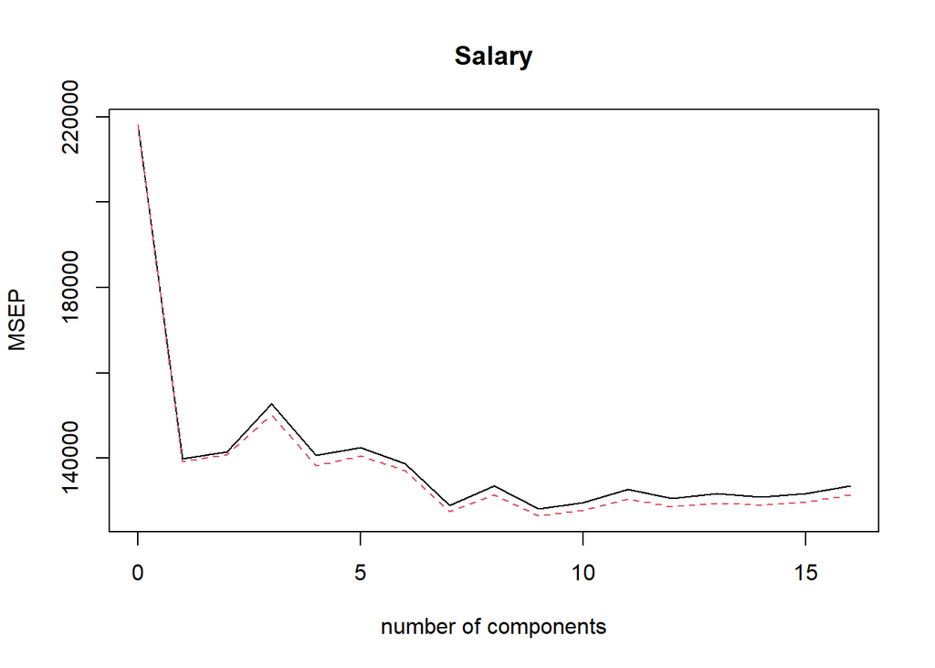

```r
validationplot(pls.fit, val.type='MSEP')
```

```r
pls.pred <- predict(pls.fit, test, ncomp=16)
sqrt(mean((pls.pred - test$Salary)^2))
```

```
## [1] 325.4804
```

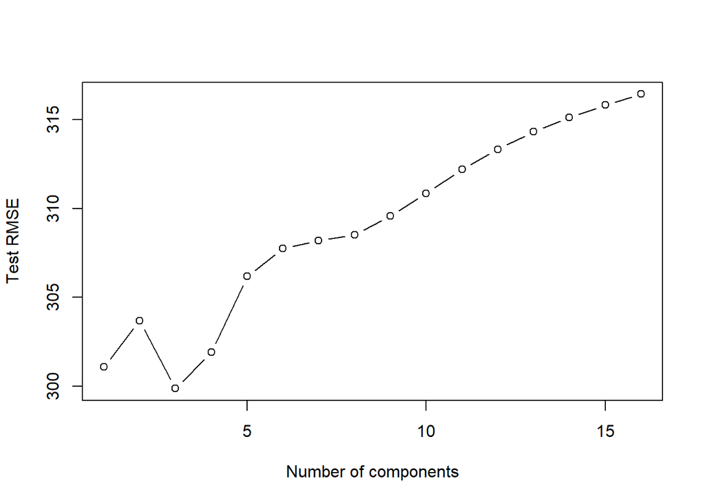

```r
# Fit PLS models with 1 to 16 components
ncomp <- 1:16
pls.rmses <- rep(NA, length(ncomp))
for (i in ncomp) {
  pls.fit <- plsr(Salary~., data=train, scale=TRUE, ncomp=i)
  pls.pred <- predict(pls.fit, test)
  pls.rmses[i] <- sqrt(mean((pls.pred - test$Salary)^2))
}

# Plot test RMSE vs number of components
plot(ncomp, pls.rmses, type="b", xlab="Number of components", ylab="Test RMSE")
```

Choosing 3 components will give the lowest Test RMSE.

*Principal Component Analysis*

#For the covariance matrix S

```r
# By default "prcomp" will perform decomposition of data that is centered but not scaled (center = TRUE, scale = FALSE)
# Calculate the principal component of covariance matrix with scaling
df= train[, -ncol(train)]
pca_S = prcomp(df)
pca_S
```

```
## Standard deviations (1, .., p=16):
##  [1] 2529.709088  296.474096  177.003479  131.467766  115.455842   91.942558
##  [7]   64.595488   36.762484   13.759469   12.746735   11.739829   10.832128
## [13]    6.736472    4.592910    2.931616    1.630134
##
## Rotation (n x k) = (16 x 16):
##                   PC1          PC2          PC3          PC4          PC5
## AtBat    1.400202e-02 -0.214650239 -0.574824770 -0.581382442  0.187617802
## Hits     4.227725e-03 -0.064589717 -0.168584474 -0.172500541  0.072793482
## HmRun    8.205623e-04 -0.010427957 -0.001327328 -0.041357853  0.007513235
## Runs     1.794635e-03 -0.031609094 -0.073632779 -0.122989149  0.025412263
## RBI      3.264442e-03 -0.037295342 -0.044425232 -0.115649723  0.031456242
## Walks    2.093472e-03 -0.021185983 -0.025804285 -0.097038948 -0.049083817
## Years    1.770556e-03  0.001793532  0.003558595  0.003458043 -0.001938136
## CAtBat   9.413514e-01  0.026739494 -0.033333686  0.145499700  0.003801696
## CHits    2.659045e-01 -0.041370776 -0.053458045  0.008261768  0.279307279
## CHmRun   2.584331e-02 -0.021978109  0.091854290 -0.256400897 -0.041730337
## CRuns    1.328776e-01 -0.010156806  0.045374212 -0.254417462 -0.056606619
## CRBI     1.240239e-01 -0.061978989  0.169828602 -0.464094931  0.028143857
## CWalks   9.586273e-02  0.028860385  0.273384868 -0.342103783 -0.774729441
## PutOuts  3.933936e-03 -0.969055082  0.143912008  0.181161932 -0.079274243
## Assists  2.218194e-03 -0.006208966 -0.702764025  0.274914856 -0.514751056
## Errors  -1.495756e-05 -0.003033290 -0.021122892  0.008534096 -0.013129646
##                  PC6          PC7          PC8           PC9         PC10
## AtBat    0.225555113  0.263601603 -0.080377517  0.2520567509  0.079331686
## Hits     0.076637811  0.016987729 -0.120210948 -0.1735315605 -0.076940238
## HmRun   -0.012910184  0.018238960  0.039228261 -0.1237993635 -0.300177151
## Runs     0.066282975  0.028174361  0.044079248 -0.4610873518  0.042853641
## RBI     -0.035818671  0.029837981 -0.014703071 -0.4385860617 -0.595761294
## Walks    0.052836615  0.025203454 -0.068838747 -0.6319360052  0.181757902
## Years   -0.002206426  0.009486424 -0.004689205 -0.0118030206 -0.006882919
## CAtBat  -0.023046913  0.291342621  0.067570931 -0.0197408358  0.005504723
## CHits    0.188797059 -0.731712622 -0.456817218  0.0793359764 -0.177122016
## CHmRun  -0.280912949 -0.007711193  0.312507301  0.2521102278 -0.587019710
## CRuns    0.296881374 -0.455096392  0.734451939 -0.0639110523  0.188353563
## CRBI    -0.741914618 -0.182897042 -0.132597576 -0.0613011590  0.305414938
## CWalks   0.296574591  0.002710851 -0.311998005  0.0837621923 -0.050624443
## PutOuts -0.004036892 -0.004643730  0.031372750  0.0002793416  0.006486943
## Assists -0.304692137 -0.257874293  0.066223034 -0.0244672009 -0.014835670
## Errors  -0.011763080 -0.006941357 -0.002669499  0.0297566426 -0.015940083
```

[output cut: 19 more lines]

```
## Hits    -0.0141601477
## HmRun    0.0123082453
## Runs    -0.0023927330
## RBI     -0.0164922362
## Walks    0.0023336587
## Years    0.9985613381
## CAtBat  -0.0050836464
## CHits    0.0073347364
## CHmRun   0.0021227930
## CRuns    0.0078803464
## CRBI     0.0011332167
## CWalks  -0.0020784798
## PutOuts  0.0005090557
## Assists  0.0011431302
## Errors   0.0448272622
```

```r
summary(pca_S)
```

```
## Importance of components:
##                              PC1       PC2       PC3       PC4       PC5
## Standard deviation     2529.7091 296.47410 177.00348 131.46777 115.45584
## Proportion of Variance    0.9749   0.01339   0.00477   0.00263   0.00203
## Cumulative Proportion     0.9749   0.98833   0.99310   0.99574   0.99777
##                             PC6      PC7      PC8      PC9     PC10     PC11
## Standard deviation     91.94256 64.59549 36.76248 13.75947 12.74673 11.73983
## Proportion of Variance  0.00129  0.00064  0.00021  0.00003  0.00002  0.00002
## Cumulative Proportion   0.99905  0.99969  0.99990  0.99992  0.99995  0.99997
##                            PC12    PC13  PC14  PC15 PC16
## Standard deviation     10.83213 6.73647 4.593 2.932 1.63
## Proportion of Variance  0.00002 0.00001 0.000 0.000 0.00
## Cumulative Proportion   0.99999 1.00000 1.000 1.000 1.00
```

-A scree graph of the eigenvalues can be plotted to visualize the proportion of variance explained by each subsequential eigenvalue

```r
# the eigenvalues are provided as;
pca_S$sdev^2
```

```
##  [1] 6.399428e+06 8.789689e+04 3.133023e+04 1.728377e+04 1.333005e+04
##  [6] 8.453434e+03 4.172577e+03 1.351480e+03 1.893230e+02 1.624792e+02
## [11] 1.378236e+02 1.173350e+02 4.538005e+01 2.109482e+01 8.594372e+00
## [16] 2.657337e+00
```

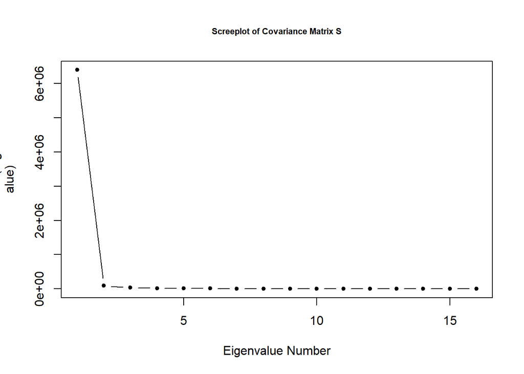

```r
# Plot the Screeplot of covariance matrix S
plot(pca_S$sdev^2, type="b", main = "Screeplot of Covariance Matrix S", xlab = 'Eigenvalue Number', ylab = "variance (Eigenv
alue)", pch=20, cex.main = 0.7)
```

To determine the appropriate number of components, we will look at the elbow of the screeplot above. The elbow occurs at around the 2nd eigenvalue number. Thus we choose 2 principle component.

-The eigenvalues of S are used to find the proportion of the total variance explained by the components as follows:

```r
variance_percent = pca_S$sdev^2/sum(pca_S$sdev^2)
variance_percent
```

```
##  [1] 9.749383e-01 1.339089e-02 4.773090e-03 2.633144e-03 2.030803e-03
##  [6] 1.287861e-03 6.356826e-04 2.058949e-04 2.884293e-05 2.475334e-05
## [11] 2.099711e-05 1.787572e-05 6.913548e-06 3.213748e-06 1.309333e-06
## [16] 4.048393e-07
```

```r
cumulative_variance_percent = cumsum(pca_S$sdev^2)/sum(pca_S$sdev^2)
cumulative_variance_percent
```

```
##  [1] 0.9749383 0.9883292 0.9931023 0.9957354 0.9977663 0.9990541 0.9996898
##  [8] 0.9998957 0.9999245 0.9999493 0.9999703 0.9999882 0.9999951 0.9999983
## [15] 0.9999996 1.0000000
```

[figure not shown]

```r
# plotting strategy
plot(cumulative_variance_percent, yaxt="n", main="Cumulative Variance Explained in S", ylab = "Proportion of Variance explai
ned", xlab = "Eigenavalue ", type = "b", ylim = c(0,1), pch=20, cex.main = 0.7)
```

The amount of total sample variance explained only increases very gradually after the second principle component. Thus the model can be explained by the second principal component(PC) effectively.

# Advanced Practice

I shall compare the feature selection methods, LASSO and PCR on these simulation models. I will do so by evaluating the accuracy with K-folds cross validation.

# Question 1

```r
library(glmnet)
library(caret)

set.seed(125) # for reproducibility
n <- 150 # number of observations
p <- 100 # number of predictors in x
ui <- 0 # mean values for predictors
si <- 1 # standard deviation values for predictors
x <- matrix(rnorm(n*p, ui, si), nrow = n)
z <- x[, 1:10] # select first 10 predictors only
log_odds <- rowSums(z) # generate outcome variable y using the logodds of predictors plus some random noise, and then converting those logodds to probabilities using the logistic function
y <- rbinom(n, 1, plogis(log_odds))

x <- data.frame(x)
z <- data.frame(z)


# Predict accuracy using k-fold cross-validation: USING LASSO REGULARIZATION
set.seed(123)
folds <- createFolds(y, k = 10, list = TRUE)
accuracy <- rep(NA, length(folds))
for (i in seq_along(folds)) {
  # Split data into training and testing sets
  x_train <- x[-folds[[i]], ]
  y_train <- y[-folds[[i]]]
  x_test <- x[folds[[i]], ]
  y_test <- y[folds[[i]]]

  # Train Lasso model on training data
  fit <- glmnet(x = as.matrix(x_train), y = y_train, family = "binomial", alpha = 1)

  # Predict test data using Lasso model
  y_pred <- predict(fit, newx = as.matrix(x_test))
  y_pred <- ifelse(y_pred > 0, 1, 0)

  # Calculate accuracy on test data
  accuracy[i] <- mean(y_pred == y_test)
}

lasso_accuracy <- mean(accuracy)
lasso_accuracy
```

```
## [1] 0.7563891
```

```r
library(pls)

set.seed(125)

n <- 150 # number of observations
p <- 100 # number of predictors in x
ui <- 0 # mean values for predictors
si <- 1 # standard deviation values for predictors

x <- matrix(rnorm(n*p, ui, si), nrow = n)
z <- x[, 1:10] # select first 10 predictors only
log_odds <- rowSums(z) # generate outcome variable y using the logodds of predictors plus some random noise, and then converting those logodds to probabilities using the logistic function
y <- rbinom(n, 1, plogis(log_odds))

x <- data.frame(x)
z <- data.frame(z)

# number of principal components to consider
k <- 10

# create a matrix of zeros to store the predicted values
y_pred <- matrix(0, nrow = n, ncol = k)

# perform k-fold cross-validation
k <- 5 # number of folds
folds <- sample(rep(1:k, length.out = n))

# calculate accuracy for each fold
cv_errors <- rep(0, k)

for (i in 1:k) {
  # split data into training and testing sets
  x_train <- x[folds != i, ]
  y_train <- y[folds != i]
  x_test <- x[folds == i, ]
  y_test <- y[folds == i]

  # perform PCR
  fit_pcr <- pcr(y_train ~ ., data = x_train, scale = TRUE, validation = "CV")

  # predict on test set
  y_pred[folds == i, ] <- predict(fit_pcr, newdata = x_test, ncomp = k)

  # calculate accuracy
  cv_errors[i] <- mean((y_pred[folds == i, ] - y_test)^2)
}

# calculate the average accuracy across all folds
pcr_accuracy <- 1 - mean(cv_errors)

cat("Accuracy:", round(accuracy, 3))
```

```
## Accuracy: 0.882 0.765 0.86 0.648 0.739 0.852 0.723 0.762 0.71 0.623
```

```r
cbind(lasso_accuracy,pcr_accuracy)
```

```
##      lasso_accuracy pcr_accuracy
## [1,]      0.7563891    0.7494924
```

LASSO performs slightly better than PCR, using k-fold cross validation to estimate the accuracy of the models.

# Question 2

```r
library(glmnet)
library(caret)

set.seed(125) # for reproducibility
n <- 150 # number of observations
p <- 100 # number of predictors in x
ui <- 0 # mean values for predictors
si <- 1 # standard deviation values for predictors
x <- matrix(rnorm(n*p, ui, si), nrow = n)
z <- x[, 1:10] # select first 10 predictors only
log_odds <- rowSums(z) # generate outcome variable y using the logodds of predictors plus some random noise, and then converting those logodds to probabilities using the logistic function
zb<- z[,1] + 2*z[,2] + 3*z[,3] + 4*z[,4] + 5*z[,5]
p <- 1/(1 + exp(-zb))
y= rbinom(n,1,prob=p)

x <- data.frame(x)
z <- data.frame(z)


# Predict accuracy using k-fold cross-validation: USING LASSO REGULARIZATION
set.seed(123)
folds <- createFolds(y, k = 10, list = TRUE)
accuracy <- rep(NA, length(folds))
for (i in seq_along(folds)) {
  # Split data into training and testing sets
  x_train <- x[-folds[[i]], ]
  y_train <- y[-folds[[i]]]
  x_test <- x[folds[[i]], ]
  y_test <- y[folds[[i]]]

  # Train Lasso model on training data
  fit <- glmnet(x = as.matrix(x_train), y = y_train, family = "binomial", alpha = 1)

  # Predict test data using Lasso model
  y_pred <- predict(fit, newx = as.matrix(x_test))
  y_pred <- ifelse(y_pred > 0, 1, 0)

  # Calculate accuracy on test data
  accuracy[i] <- mean(y_pred == y_test)
}

lasso_accuracy <- mean(accuracy)
lasso_accuracy
```

```
## [1] 0.8886394
```

```r
library(pls)

set.seed(125)

n <- 150 # number of observations
p <- 100 # number of predictors in x
ui <- 0 # mean values for predictors
si <- 1 # standard deviation values for predictors

x <- matrix(rnorm(n*p, ui, si), nrow = n)
z <- x[, 1:10] # select first 10 predictors only
log_odds <- rowSums(z) # generate outcome variable y using the logodds of predictors plus some random noise, and then converting those logodds to probabilities using the logistic function
zb<- z[,1] + 2*z[,2] + 3*z[,3] + 4*z[,4] + 5*z[,5]
p <- 1/(1 + exp(-zb))
y= rbinom(n,1,prob=p)

x <- data.frame(x)
z <- data.frame(z)

# number of principal components to consider
k <- 10

# create a matrix of zeros to store the predicted values
y_pred <- matrix(0, nrow = n, ncol = k)

# perform k-fold cross-validation
k <- 5 # number of folds
folds <- sample(rep(1:k, length.out = n))

# calculate accuracy for each fold
cv_errors <- rep(0, k)

for (i in 1:k) {
  # split data into training and testing sets
  x_train <- x[folds != i, ]
  y_train <- y[folds != i]
  x_test <- x[folds == i, ]
  y_test <- y[folds == i]

  # perform PCR
  fit_pcr <- pcr(y_train ~ ., data = x_train, scale = TRUE, validation = "CV")

  # predict on test set
  y_pred[folds == i, ] <- predict(fit_pcr, newdata = x_test, ncomp = k)

  # calculate accuracy
  cv_errors[i] <- mean((y_pred[folds == i, ] - y_test)^2)
}

# calculate the average accuracy across all folds
pcr_accuracy <- 1 - mean(cv_errors)

pcr_accuracy
```

```
## [1] 0.7554506
```

```r
cat("Accuracy:", round(accuracy, 3))
```

```
## Accuracy: 0.853 0.912 0.896 0.831 0.888 0.97 0.844 0.97 0.795 0.929
```

```r
cbind(lasso_accuracy,pcr_accuracy)
```

```
##      lasso_accuracy pcr_accuracy
## [1,]      0.8886394    0.7554506
```

LASSO performs better than PCR, using k-fold cross validation to estimate the accuracy of the models.

# Question 3

```r
library(glmnet)
library(caret)

set.seed(125) # for reproducibility
n <- 150 # number of observations
p <- 100 # number of predictors in x
ui <- 0 # mean values for predictors
si <- 1 # standard deviation values for predictors
x <- matrix(rnorm(n*p, ui, si), nrow = n)
z <- x[, 1:10] # select first 10 predictors only
log_odds <- rowSums(z) # generate outcome variable y using the logodds of predictors plus some random noise, and then converting those logodds to probabilities using the logistic function
#let b1=1, b2=2, b3=3, b4=4, b5=4
zb<- z[,1] + 2*z[,2] + 3*z[,3] + 4*z[,4] + 5*z[,5]
p <- (tanh(zb)+1)/2
y= rbinom(n,1,prob=p)

x <- data.frame(x)
z <- data.frame(z)


# Predict accuracy using k-fold cross-validation: USING LASSO REGULARIZATION
set.seed(123)
folds <- createFolds(y, k = 10, list = TRUE)
accuracy <- rep(NA, length(folds))
for (i in seq_along(folds)) {
  # Split data into training and testing sets
  x_train <- x[-folds[[i]], ]
  y_train <- y[-folds[[i]]]
  x_test <- x[folds[[i]], ]
  y_test <- y[folds[[i]]]

  # Train Lasso model on training data
  fit <- glmnet(x = as.matrix(x_train), y = y_train, family = "binomial", alpha = 1)

  # Predict test data using Lasso model
  y_pred <- predict(fit, newx = as.matrix(x_test))
  y_pred <- ifelse(y_pred > 0, 1, 0)

  # Calculate accuracy on test data
  accuracy[i] <- mean(y_pred == y_test)
}

lasso_accuracy <- mean(accuracy)
lasso_accuracy
```

```
## [1] 0.8608955
```

```r
library(pls)

set.seed(125)

n <- 150 # number of observations
p <- 100 # number of predictors in x
ui <- 0 # mean values for predictors
si <- 1 # standard deviation values for predictors

x <- matrix(rnorm(n*p, ui, si), nrow = n)
z <- x[, 1:10] # select first 10 predictors only
log_odds <- rowSums(z) # generate outcome variable y using the logodds of predictors plus some random noise, and then converting those logodds to probabilities using the logistic function
#let b1=1, b2=2, b3=3, b4=4, b5=4
zb<- z[,1] + 2*z[,2] + 3*z[,3] + 4*z[,4] + 5*z[,5]
p <- (tanh(zb)+1)/2
y= rbinom(n,1,prob=p)

x <- data.frame(x)
z <- data.frame(z)

# number of principal components to consider
k <- 10

# create a matrix of zeros to store the predicted values
y_pred <- matrix(0, nrow = n, ncol = k)

# perform k-fold cross-validation
k <- 5 # number of folds
folds <- sample(rep(1:k, length.out = n))

# calculate accuracy for each fold
cv_errors <- rep(0, k)

for (i in 1:k) {
  # split data into training and testing sets
  x_train <- x[folds != i, ]
  y_train <- y[folds != i]
  x_test <- x[folds == i, ]
  y_test <- y[folds == i]

  # perform PCR
  fit_pcr <- pcr(y_train ~ ., data = x_train, scale = TRUE, validation = "CV")

  # predict on test set
  y_pred[folds == i, ] <- predict(fit_pcr, newdata = x_test, ncomp = k)

  # calculate accuracy
  cv_errors[i] <- mean((y_pred[folds == i, ] - y_test)^2)
}

# calculate the average accuracy across all folds
pcr_accuracy <- 1 - mean(cv_errors)

pcr_accuracy
```

```
## [1] 0.7743379
```

```r
cat("Accuracy:", round(accuracy, 3))
```

```
## Accuracy: 0.951 0.903 0.834 0.826 0.764 0.911 0.871 0.851 0.768 0.93
```

```r
cbind(lasso_accuracy,pcr_accuracy)
```

```
##      lasso_accuracy pcr_accuracy
## [1,]      0.8608955    0.7743379
```

LASSO performs better than PCR, using k-fold cross validation to estimate the accuracy of the models.

# Question 4

```r
library(glmnet)
library(caret)

set.seed(125) # for reproducibility
n <- 150 # number of observations
p <- 100 # number of predictors in x
ui <- 0 # mean values for predictors
si <- 1 # standard deviation values for predictors
x <- matrix(rnorm(n*p, ui, si), nrow = n)
z <- x[, 1:10] # select first 10 predictors only
log_odds <- rowSums(z) # generate outcome variable y using the logodds of predictors plus some random noise, and then converting those logodds to probabilities using the logistic function
#let b1=1, b2=2, b3=3, b4=4, b5=4
zb<- z[,1] + 2*z[,2] + 3*z[,3] + 4*z[,4] + 5*z[,5]
p <- (atan(zb)+ (pi/2))/pi
y= rbinom(n,1,prob=p)

x <- data.frame(x)
z <- data.frame(z)


# Predict accuracy using k-fold cross-validation: USING LASSO REGULARIZATION
set.seed(123)
folds <- createFolds(y, k = 10, list = TRUE)
accuracy <- rep(NA, length(folds))
for (i in seq_along(folds)) {
  # Split data into training and testing sets
  x_train <- x[-folds[[i]], ]
  y_train <- y[-folds[[i]]]
  x_test <- x[folds[[i]], ]
  y_test <- y[folds[[i]]]

  # Train Lasso model on training data
  fit <- glmnet(x = as.matrix(x_train), y = y_train, family = "binomial", alpha = 1)

  # Predict test data using Lasso model
  y_pred <- predict(fit, newx = as.matrix(x_test))
  y_pred <- ifelse(y_pred > 0, 1, 0)

  # Calculate accuracy on test data
  accuracy[i] <- mean(y_pred == y_test)
}

lasso_accuracy <- mean(accuracy)
lasso_accuracy
```

```
## [1] 0.7904485
```

```r
library(pls)

set.seed(125)

n <- 150 # number of observations
p <- 100 # number of predictors in x
ui <- 0 # mean values for predictors
si <- 1 # standard deviation values for predictors

x <- matrix(rnorm(n*p, ui, si), nrow = n)
z <- x[, 1:10] # select first 10 predictors only
log_odds <- rowSums(z) # generate outcome variable y using the logodds of predictors plus some random noise, and then converting those logodds to probabilities using the logistic function
#let b1=1, b2=2, b3=3, b4=4, b5=4
zb<- z[,1] + 2*z[,2] + 3*z[,3] + 4*z[,4] + 5*z[,5]
p <- (atan(zb)+ (pi/2))/pi
y= rbinom(n,1,prob=p)

x <- data.frame(x)
z <- data.frame(z)

# number of principal components to consider
k <- 10

# create a matrix of zeros to store the predicted values
y_pred <- matrix(0, nrow = n, ncol = k)

# perform k-fold cross-validation
k <- 5 # number of folds
folds <- sample(rep(1:k, length.out = n))

# calculate accuracy for each fold
cv_errors <- rep(0, k)

for (i in 1:k) {
  # split data into training and testing sets
  x_train <- x[folds != i, ]
  y_train <- y[folds != i]
  x_test <- x[folds == i, ]
  y_test <- y[folds == i]

  # perform PCR
  fit_pcr <- pcr(y_train ~ ., data = x_train, scale = TRUE, validation = "CV")

  # predict on test set
  y_pred[folds == i, ] <- predict(fit_pcr, newdata = x_test, ncomp = k)

  # calculate accuracy
  cv_errors[i] <- mean((y_pred[folds == i, ] - y_test)^2)
}

# calculate the average accuracy across all folds
pcr_accuracy <- 1 - mean(cv_errors)

pcr_accuracy
```

```
## [1] 0.7563569
```

```r
cat("Accuracy:", round(accuracy, 3))
```

```
## Accuracy: 0.842 0.839 0.754 0.844 0.745 0.917 0.769 0.732 0.625 0.839
```

```r
cbind(lasso_accuracy,pcr_accuracy)
```

```
##      lasso_accuracy pcr_accuracy
## [1,]      0.7904485    0.7563569
```

LASSO performs slightly better than PCR, using k-fold cross validation to estimate the accuracy of the models.

# Question 5

```r
library(glmnet)
library(caret)

set.seed(125) # for reproducibility
n <- 150 # number of observations
m=100 #Total number of predictors
p=0.86 #probability
x<- matrix(rbinom(n*m,1,p),nrow=n)
z <- x[, 1:2] # select first 2 predictors only
#generate outcome variables
#let b1=1, b2=1
y <- (z[,1] + z[,2] )%%2

x <- data.frame(x)
z <- data.frame(z)


# Predict accuracy using k-fold cross-validation: USING LASSO REGULARIZATION
set.seed(123)
folds <- createFolds(y, k = 10, list = TRUE)
accuracy <- rep(NA, length(folds))
for (i in seq_along(folds)) {
  # Split data into training and testing sets
  x_train <- x[-folds[[i]], ]
  y_train <- y[-folds[[i]]]
  x_test <- x[folds[[i]], ]
  y_test <- y[folds[[i]]]

  # Train Lasso model on training data
  fit <- glmnet(x = as.matrix(x_train), y = y_train, family = "binomial", alpha = 1)

  # Predict test data using Lasso model
  y_pred <- predict(fit, newx = as.matrix(x_test))
  y_pred <- ifelse(y_pred > 0, 1, 0)

  # Calculate accuracy on test data
  accuracy[i] <- mean(y_pred == y_test)
}

lasso_accuracy <- mean(accuracy)
lasso_accuracy
```

```
## [1] 0.8494606
```

```r
library(pls)

set.seed(125)


n=1000 #number of observations
set.seed(125) # for reproducibility
n <- 150 # number of observations
m=100 #Total number of predictors
p=0.86 #probability
x<- matrix(rbinom(n*m,1,p),nrow=n)
z <- x[, 1:2] # select first 2 predictors only
#generate outcome variables
#let b1=1, b2=1
y <- (z[,1] + z[,2] )%%2

x <- data.frame(x)
z <- data.frame(z)
# number of principal components to consider
k <- 10

# create a matrix of zeros to store the predicted values
y_pred <- matrix(0, nrow = n, ncol = k)

# perform k-fold cross-validation
k <- 5 # number of folds
folds <- sample(rep(1:k, length.out = n))

# calculate accuracy for each fold
cv_errors <- rep(0, k)

for (i in 1:k) {
  # split data into training and testing sets
  x_train <- x[folds != i, ]
  y_train <- y[folds != i]
  x_test <- x[folds == i, ]
  y_test <- y[folds == i]

  # perform PCR
  fit_pcr <- pcr(y_train ~ ., data = x_train, scale = TRUE, validation = "CV")

  # predict on test set
  y_pred[folds == i, ] <- predict(fit_pcr, newdata = x_test, ncomp = k)

  # calculate accuracy
  cv_errors[i] <- mean((y_pred[folds == i, ] - y_test)^2)
}

# calculate the average accuracy across all folds
pcr_accuracy <- 1 - mean(cv_errors)

pcr_accuracy
```

```
## [1] 0.8317001
```

```r
cat("Accuracy:", round(accuracy, 3))
```

```
## Accuracy: 0.805 0.899 0.933 0.83 0.794 0.873 0.802 0.898 0.923 0.738
```

```r
cbind(lasso_accuracy,pcr_accuracy)
```

```
##      lasso_accuracy pcr_accuracy
## [1,]      0.8494606    0.8317001
```

LASSO performs slightly better than PCR, using k-fold cross validation to estimate the accuracy of the models.

# Question 6

Relationship: f(Y) is a Gudermannian function, where P(Y=1)= 2*arctan(tanh(x/2))

We shall let P(Y=1)= (pi/2 +2*arctan(tanh(2z1 + 3z2/2)))/pi where z1,z2 are i.i.d from N(ui,si)

```r
library(glmnet)
library(caret)

set.seed(125) # for reproducibility
n <- 150 # number of observations
p <- 100 # number of predictors in x
ui <- 0 # mean values for predictors
si <- 1 # standard deviation values for predictors
x <- matrix(rnorm(n*p, ui, si), nrow = n)
z <- x[, 1:2] # select first 2 predictors only
log_odds <- rowSums(z) # generate outcome variable y using the logodds of predictors plus some random noise, and then converting those logodds #let b1=2, b2=3
p <- (2*atan(tanh((2*z[,1]+3*z[,2])/2)) + pi/2)/pi
y= rbinom(n,1,prob=p)

x <- data.frame(x)
z <- data.frame(z)


# Predict accuracy using k-fold cross-validation: USING LASSO REGULARIZATION
set.seed(123)
folds <- createFolds(y, k = 10, list = TRUE)
accuracy <- rep(NA, length(folds))
for (i in seq_along(folds)) {
  # Split data into training and testing sets
  x_train <- x[-folds[[i]], ]
  y_train <- y[-folds[[i]]]
  x_test <- x[folds[[i]], ]
  y_test <- y[folds[[i]]]

  # Train Lasso model on training data
  fit <- glmnet(x = as.matrix(x_train), y = y_train, family = "binomial", alpha = 1)

  # Predict test data using Lasso model
  y_pred <- predict(fit, newx = as.matrix(x_test))
  y_pred <- ifelse(y_pred > 0, 1, 0)

  # Calculate accuracy on test data
  accuracy[i] <- mean(y_pred == y_test)
}

lasso_accuracy <- mean(accuracy)
lasso_accuracy
```

```
## [1] 0.7534462
```

```r
library(pls)

set.seed(125) # for reproducibility
n <- 150 # number of observations
p <- 100 # number of predictors in x
ui <- 0 # mean values for predictors
si <- 1 # standard deviation values for predictors
x <- matrix(rnorm(n*p, ui, si), nrow = n)
z <- x[, 1:2] # select first 2 predictors only
log_odds <- rowSums(z) # generate outcome variable y using the logodds of predictors plus some random noise, and then converting those logodds #let b1=2, b2=3
p <- (2*atan(tanh((2*z[,1]+3*z[,2])/2)) + pi/2)/pi
y= rbinom(n,1,prob=p)

x <- data.frame(x)
z <- data.frame(z)

# number of principal components to consider
k <- 10

# create a matrix of zeros to store the predicted values
y_pred <- matrix(0, nrow = n, ncol = k)

# perform k-fold cross-validation
k <- 5 # number of folds
folds <- sample(rep(1:k, length.out = n))

# calculate accuracy for each fold
cv_errors <- rep(0, k)

for (i in 1:k) {
  # split data into training and testing sets
  x_train <- x[folds != i, ]
  y_train <- y[folds != i]
  x_test <- x[folds == i, ]
  y_test <- y[folds == i]

  # perform PCR
  fit_pcr <- pcr(y_train ~ ., data = x_train, scale = TRUE, validation = "CV")

  # predict on test set
  y_pred[folds == i, ] <- predict(fit_pcr, newdata = x_test, ncomp = k)

  # calculate accuracy
  cv_errors[i] <- mean((y_pred[folds == i, ] - y_test)^2)
}

# calculate the average accuracy across all folds
pcr_accuracy <- 1 - mean(cv_errors)

pcr_accuracy
```

```
## [1] 0.7636581
```

```r
cat("Accuracy:", round(accuracy, 3))
```

```
## Accuracy: 0.637 0.761 0.735 0.733 0.791 0.801 0.736 0.741 0.737 0.863
```

```r
cbind(lasso_accuracy,pcr_accuracy)
```

```
##      lasso_accuracy pcr_accuracy
## [1,]      0.7534462    0.7636581
```

PCR performs slightly better than LASSO, using k-fold cross validation to estimate the accuracy of the models.

In totality, LASSO seems to perform better than PCR.